# R Notebook

```r
library(dplyr)
source("~/GitHub/Course_Project_2/SourceCode.R")
NEI  <- nei()
SCC  <- scc()
str(NEI)
```

```
## 'data.frame':    6497651 obs. of  6 variables:
##  $ fips     : chr  "09001" "09001" "09001" "09001" ...
##  $ SCC      : chr  "10100401" "10100404" "10100501" "10200401" ...
##  $ Pollutant: chr  "PM25-PRI" "PM25-PRI" "PM25-PRI" "PM25-PRI" ...
##  $ Emissions: num  15.714 234.178 0.128 2.036 0.388 ...
##  $ type     : chr  "POINT" "POINT" "POINT" "POINT" ...
##  $ year     : int  1999 1999 1999 1999 1999 1999 1999 1999 1999 1999 ...
```

1. **Have total emissions from PM2.5 decreased in the United States from 1999 to 2008? Using the base plotting system, make a plot showing the total PM2.5 emission from all sources for each of the years 1999, 2002, 2005, and 2008.**

   the answer is yes as we can evidence in the following graph. This graph is in millions Tons for a better understanding:

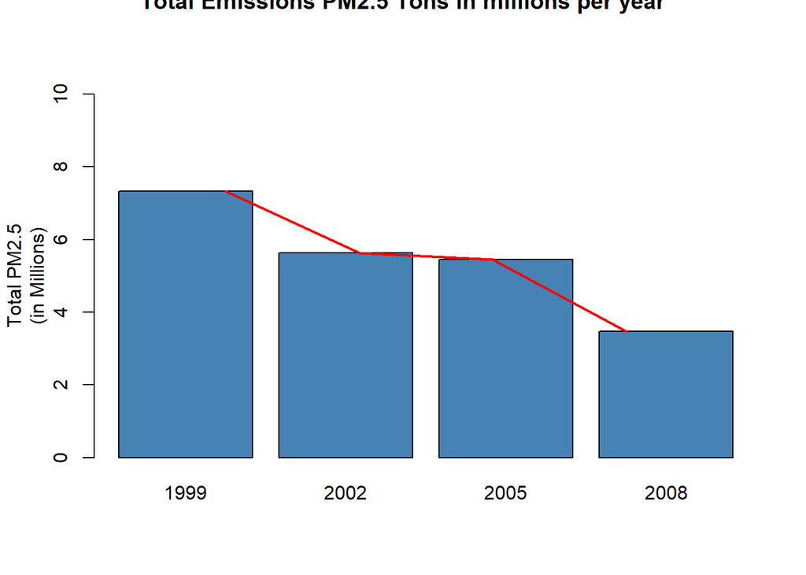

```r
  x <-NEI %>% group_by(year) %>% summarise (sum(Emissions)/1000000)
  colnames(x) <- c("year", "total_PM2.5" )

  with( x, {
    barplot(total_PM2.5, ylab = "Total PM2.5", ylim = c(0, 10), names.arg = year, col="steelblue")
    text(year, total_PM2.5 + 1, labels = as.character(round(total_PM2.5,2)))
    lines(total_PM2.5,  lwd = 2,col="red",lty=1)
    mtext(2,text="(in Millions)",line=2)

})
title(main="Total Emissions PM2.5 Tons in millions per year", outer = T)
```

```r
  x  <- NEI %>% filter(fips == "24510")  %>%   group_by(year)  %>% summarise(sum(Emissions))
  colnames(x) <- c("year", "total_PM2.5" )
```

We could say that, in general, it has decreased. we only have an exception in 2005 but as we can see the statistical trend is negative.

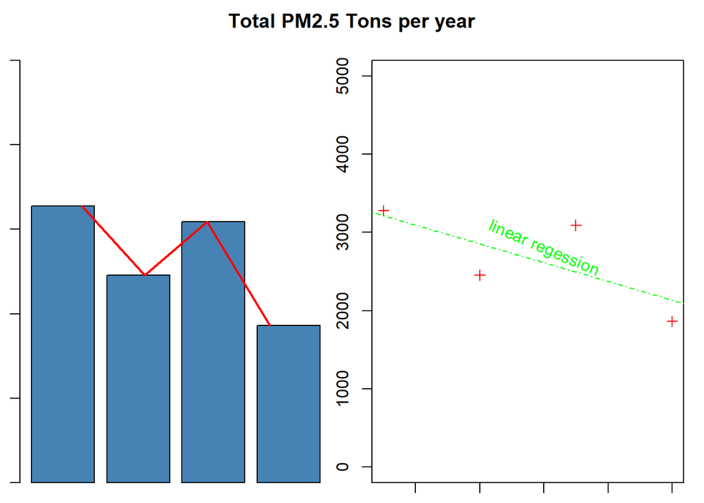

```r
  x  <- NEI %>% filter(fips == "24510")  %>%   group_by(year)  %>% summarise(sum(Emissions))
  colnames(x) <- c("year", "total_PM2.5" )

  par (mfcol = c(1,2), mar=c(1,1,1,1), oma = c(0,0,2,0))
  with(x ,{
            barplot(x$total_PM2.5, ylab = "Total PM2.5",xlab = "years", ylim = c(0, 5000), names.arg = x$year, col="steelblue")
            text(year, total_PM2.5 + 100, labels = as.character(round(x$total_PM2.5)))
            lines( total_PM2.5, lwd = 2,col="red",lty=1)
            mtext(2,text="Total",line=2, outer= TRUE)

            }
        )
  with(x ,{
            plot ( year,  total_PM2.5 , col = "red", pch = 3, ylim= c(0,5000), ylab = "Total PM2.5", xlab = "years")
            lo <- lm(total_PM2.5~year)
            abline(lo, col="green", lty ="dotdash")
            text (x= 2004, 2800, "linear regession", srt = -23, col = "green")
            title(main="Total PM2.5 Tons per year", outer = T)
          }
      )
```

```r
library(ggplot2)
x <- NEI  %>% filter(fips == "24510")  %>%  group_by(across(c(year, type))) %>%  summarise (sum(Emissions))
colnames(x) <- c("year", "type", "Emissions")
```

```r
x <- NEI  %>% filter(fips == "24510")  %>%  group_by(across(c(year, type))) %>%  summarise (sum(Emissions))
```

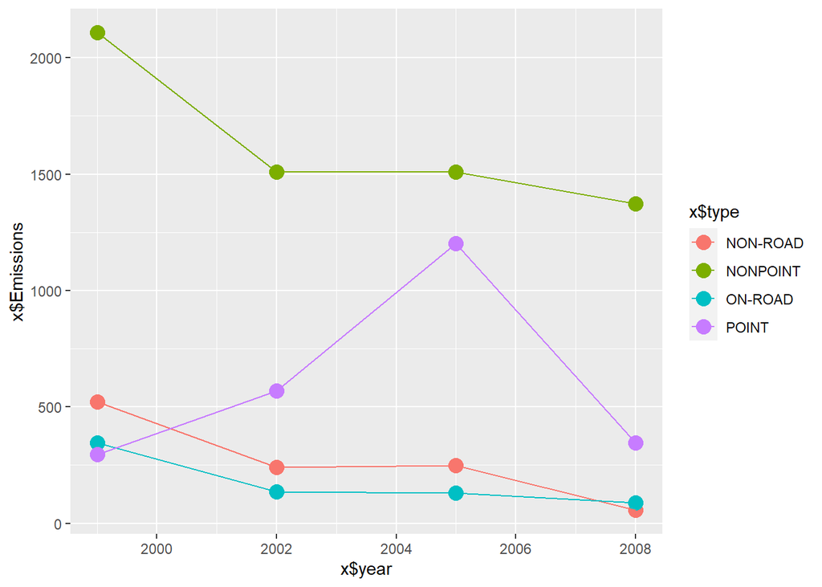

```r
colnames(x) <- c("year", "type", "Emissions")
g <-ggplot(x)
g + geom_point (aes(x$year, x$Emissions, color=x$type), lwd = 4 ) +
  geom_line (aes(x$year, x$Emissions, color=x$type)   )
```

1. **Across the United States, how have emissions from coal combustion-related sources changed from 1999–2008?**

```r
x <- inner_join(NEI, SCC, by = c("SCC" = "SCC"))
y  <-  x %>% filter (grepl('[Cc]oal', x$SCC.Level.Three)) %>% group_by(year) %>% summarise(sum(Emissions))
```

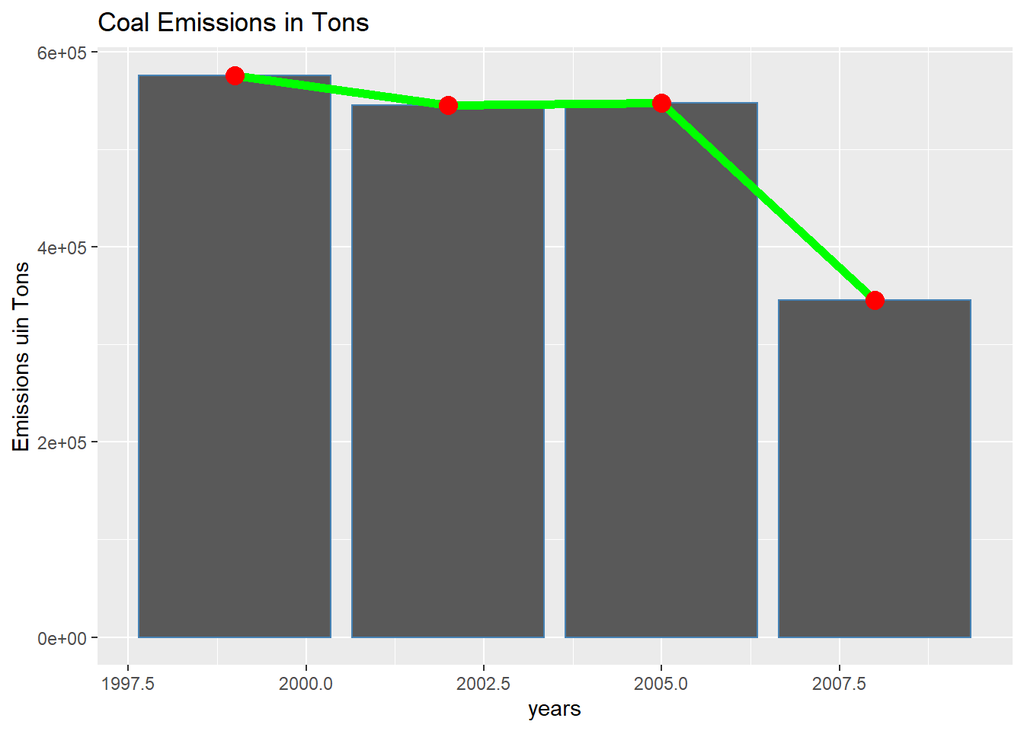

```r
g  <-  ggplot(y)
g + geom_col(aes(y$year, y$`sum(Emissions)`),col="steelblue") + geom_line(aes(y$year, y$`sum(Emissions)`), lwd = 2, col = "green") + geom_point(aes(y$year, y$`sum(Emissions)`), lwd = 4 , col = "red") + labs( x= "years", y = "Emissions uin Tons") + ggtitle( "Coal Emissions in Tons")
```